# Cvičenie 2: Autoregresné procesy

# 1 Inštalácia knižníc v R-ku

Začneme s inštaláciou knižníc potrebných na toto cvičenie. Spustením nasledovného príkazu sa nainštalujú tie z knižníc, ktoré nainštalované nie sú, a zároveň sa aj načítajú.

```r
# názvy balíkov, ktoré budú potrebné pre cvičenie 2
packages <- c("astsa","priceR","datasets","forecast","WDI","ggplot2")

# inštalácia balíkov, ak nie sú nainštalované
installed_packages <- packages %in% rownames(installed.packages())
if (any(installed_packages == FALSE)) {
  install.packages(
  packages[!installed_packages],
  dependencies = TRUE,
  repos = "https://cloud.r-project.org"
)
}

# načítanie balíkov
invisible(lapply(packages, library, character.only = TRUE))
```

# 2 Overovanie stacionarity AR procesu v R-ku

V prípade AR(1) procesu, je overovanie stacionarity zrejmé - stačí sa pozrieť na absolútnu hodnotu autoregresného koeficientu, ktorý musí byť v absolútnej hodnote menší ako 1.

Pre všeobecný AR(p) proces je v prednáškach odvodená podmienka stacionarity:

Proces $(1-\alpha_1 L - \alpha_2 L^2 - \dots \alpha_p L^p)x_t = \delta + u_t$ je stacionárny práve vtedy, keď sú všetky korene polynómu $1-\alpha_1 L - \alpha_2 L^2 - \dots \alpha_p L^p$ v absolútnej hodnote väčšie ako 1 (geometricky: mimo jednotkového kruhu).

*V R-ku:* Korene polynómu $1-\alpha_1 L - \alpha_2 L^2 - \dots \alpha_p L^p$ nájdeme pomocou funkcie `polyroot`.

## 2.1 Príklad: Overenie stacionarity AR(2) procesu

*Zadanie:* Zistíme, či je proces $(1−0.9L+0.6L2^)x_t=u_t$ stacionárny.

*Výpočet v R-ku:* Hľadáme korene (a ich absolútne hodnoty) polynómu $1−0.9L+0.6L^2$, teda:

```r
polyroot(c(...)) # korene polynómu
abs(polyroot(c(...))) # absolútne hodnoty koreňov polynómu
```

```
## [1] 0.75+1.050793i 0.75-1.050793i
```

```
## [1] 1.290994 1.290994
```

*Záver:* Korene sú mimo jednotkového kruhu, lebo absoútne hodnota je pre každý koreň väčšia ako 1. Teda náš proces JE STACIONÁRNY.

## 2.2 Cvičenie: Overenie stacionarity AR procesu (súčasť kostry na skúške)

Zistite, či sú nasledovné AR procesy stacionárne:

- $(1 + 0.3L + 0.2L^2)x_t = 5+u_t$
- $(1 - 0.25L + 0.6L^2 - 0.55L^3)x_t = u_t$
- $x_t = 0.8x_{t-1} + 0.3x_{t-2} + 0.2x_{t-3} + u_t$
- $x_t = 0.25 + 0.1x_{t-1} + 0.2x_{t-3} + u_t$

Vypočítajte strednú hodnotu stacionárnych procesov.

## 2.3 Cvičenie: Grafické znázornenie koreňov

Znázornite korene polynómov z predošlého cvičenia v komplexnej rovine spolu s jednotkovým kruhom.

Užitočné funkcie a parametre:

- ak dostne `plot` ako vstup komplexné čísla, nakreslí na x-ovú os ich reálnu a na y-ovú os imaginárnu časť
- parameter `asp = 1` zabezpečí rovnakú mierku na obidvoch osiach
- funkcia `curve` nakreslí zadanú krivku pre zadaný rozsah nezávislej premennej, s parameterom `add = TRUE` ju dokreslí do pôvodného obrázku
- osi môžeme kresliť pomocou `abline` (horizontálnu s parametrom `h`, vertikálnu s parametrom `v`)

## 2.4 Cvičenie: Nájdenie príkladu procesu s danou vlastnosťou

Nájdite príklad

- stacionárneho AR(3) procesu
- nestacionárneho AR(4) procesu
- stacionárneho AR(2) procesu, ktorého stredná hodnota je rovná 15

V každom z týchto prípadov dokážte, že váš proces naozaj má požadovanú vlastnosť.

Príklady tohto typu “nájdite príklad procesu, ktorý … a ukážte, že má požadovanú vlastnosť” budú aj na skúške.

# 3 Hľadanie AR modelu

V tejto časti budeme modelovať infláciu. Z balíka `priceR` použijeme príkaz `retrieve_inflation_data` na získanie dát z *World Bank API*.

```r
retrieve_inflation_data(country, countries_dataframe)
```

Budeme skúmať infláciu v USA. Zvoľme teda `country=“US”’.

```r
data <- retrieve_inflation_data("US")
```

```
## Validating iso2Code for US
## Generating URL to request all 296 results
## Retrieving inflation data for US
## Generating URL to request all 66 results
```

```r
str(data)
```

```
## 'data.frame':    66 obs. of  8 variables:
##  $ indicator      :'data.frame': 66 obs. of  2 variables:
##   ..$ id   : chr  "FP.CPI.TOTL.ZG" "FP.CPI.TOTL.ZG" "FP.CPI.TOTL.ZG" "FP.CPI.TOTL.ZG" ...
##   ..$ value: chr  "Inflation, consumer prices (annual %)" "Inflation, consumer prices (annual %)" "Inflation, consumer prices (annual %)" "Inflation, consumer prices (annual %)" ...
##  $ country        :'data.frame': 66 obs. of  2 variables:
##   ..$ id   : chr  "US" "US" "US" "US" ...
##   ..$ value: chr  "United States" "United States" "United States" "United States" ...
##  $ countryiso3code: chr  "USA" "USA" "USA" "USA" ...
##  $ date           : chr  "2025" "2024" "2023" "2022" ...
##  $ value          : num  NA 2.95 4.12 8 4.7 ...
##  $ unit           : chr  "" "" "" "" ...
##  $ obs_status     : chr  "" "" "" "" ...
##  $ decimal        : int  1 1 1 1 1 1 1 1 1 1 ...
```

Po vykreslení časového radu $x$ by ste mali dostať nasledovný priebeh:

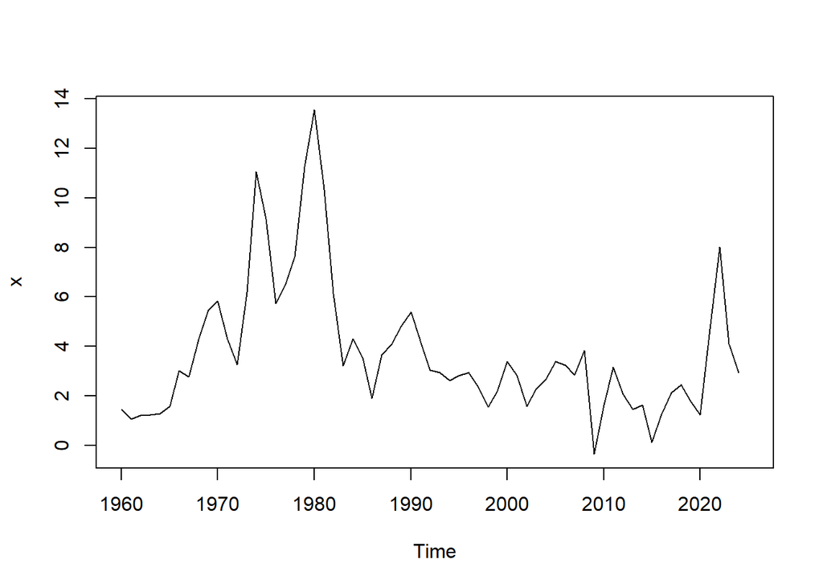

```r
plot(x)
```

Neskôr uvidíme, že takéto dáta treba diferencovať, aj keď v nich nie je trend. Preto teraz **budeme pracovať s diferenciami** . Pri modelovaní si treba uvedomiť, že **konštantný člen v modeli pre diferencie znamená lineárny trend v pôvodných dátach** a tento trend sa dostane aj do predikcií.

- V dátach o inflácii nie je trend $\Rightarrow$ chceme odhadnúť model pre diferencie *bez konštanty*
- Vo funkcii `sarima` pridáme parameter `no.constant` na `TRUE`
- Ak sa diferencuje viac ako raz, spraví sa to automaticky

```r
# ar(p) model bez konstanty pre 1. diferencie
sarima(data, p, 1, 0, no.constant = TRUE)
```

## 3.1 Úlohy

- Pre diferencie zistite či sú pre ne na základe rezíduí dobrými modelmi AR(p) pre $p \in \{0, 1, 2,3,4,5 \}$ bez konštanty
- Z vyhovujúcich modelov vyberte ten, ktorý má najnižšie BIC.

Zopakujte pre infláciu v štátoch (všade treba diferencovať):

- Francúzsko (FR)
- Japonsko (JP)
- Kanada (CA)

# 4 Konštrukcia predikcií

Cieľom modelovania je často konštrukcia predikcií do budúcnosti. V R-ku na to existuje funkcia `sarima.for`.

```r
sarima.for(data, n, p, 0, 0)  # predikcie pre n pozorovani z AR(p) modelu
sarima.for(data, n, p, k, 0)  # predikcie pre n pozorovani premennej data, ak jej k-te diferencie modelujeme ako AR(p)
```

Vynechajte z dát posledných 10 pozorovaní.

```r
x_skratene <- window(x, start=1960, end=2013)
```

Zo zostávajúcich dát odhadnite AR model pre diferencie bez konštanty, ktorý má najmenšie BIC. Pomocou funkcie `sarima.for` spravte predikcie pre nasledujúcich 10 rokov. Mali by ste dostať výstup:

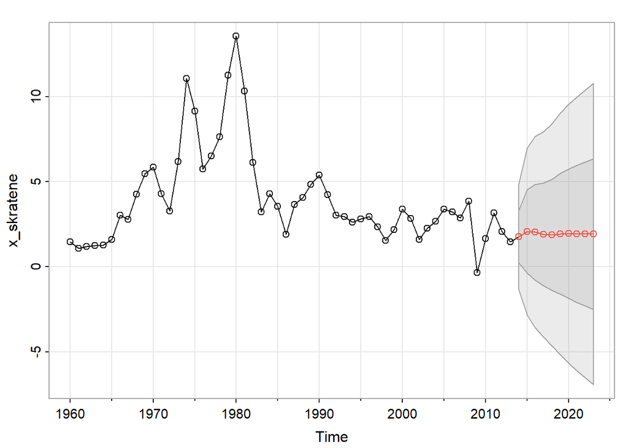

Nakreslite do jedného grafu farebne odlíšené: dáta použité na odhadovanie modelu, predikcie, predikcie +/- 2 ′× štandardná odchýlka, skutočný vývoj v posledných desiatich rokoch. Na to sa dá dobre využiť funkcia ts.plot. Príklad použitia:

```r
 ts.plot(data1, data2, data3,
        gpars=list(xlab="time", ylab="popis dat",
                  col=c("red","blue","black"))
)
```

Výsledok pre porovnanie:

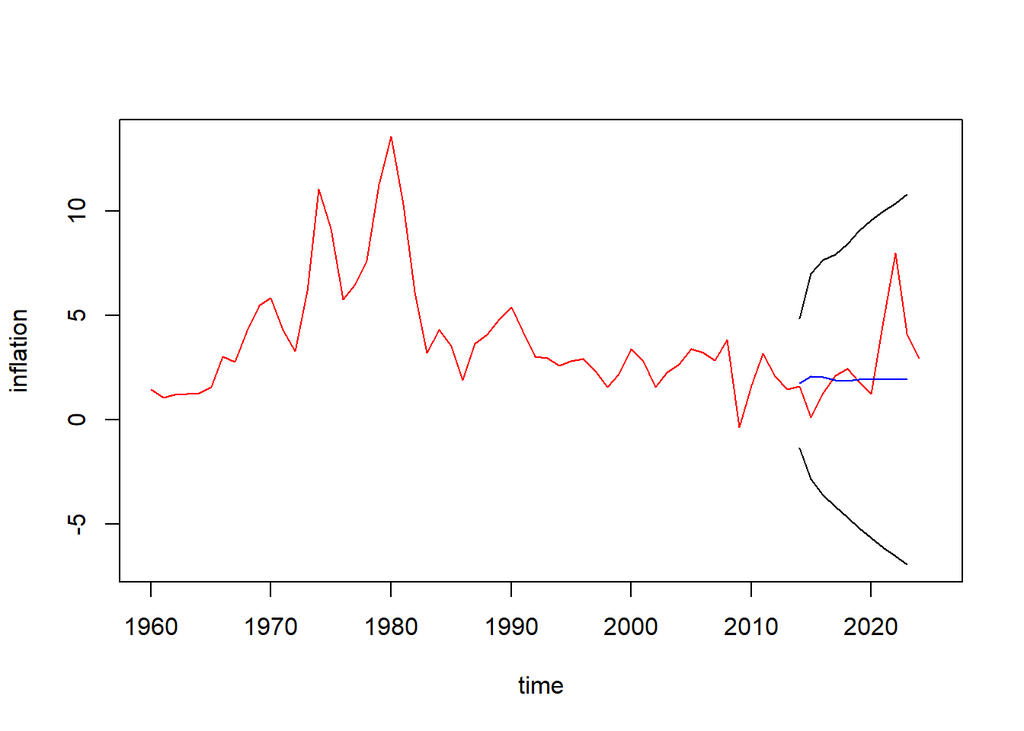

# 5 Zautomatizovanie testovania viacerých AR modelov

Uvažujme dáta o prietokoch Nílu z Cvičenia 1.

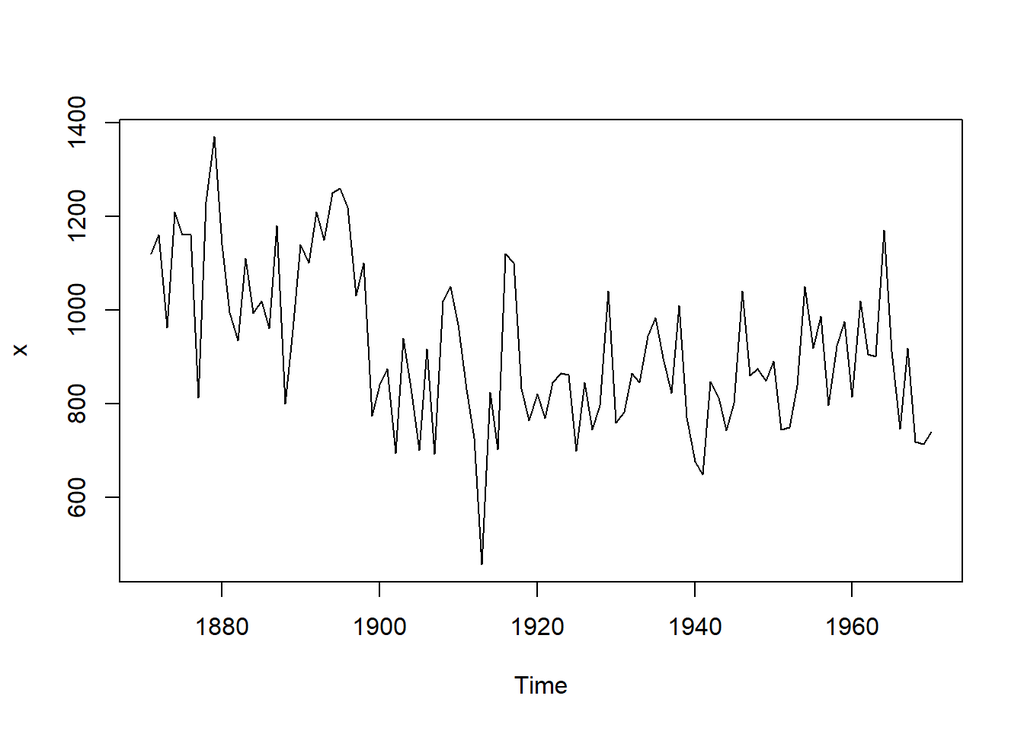

```r
x <- Nile
plot(x)
```

**Prípravná úloha:** Odhadujeme pre dáta AR(2) model. Čomu sa rovná p-hodnota z Ljung-Boxovho testu pre rezíduá, ak testujeme nulovosť prvých piatich autokorelácií?

```r
# POSTUP
model <- sarima(...)    # odhadneme model
model$...               # chceme pristupovat k reziduam
Box.test(..., fitdf = ) # Ljung-Boxov test pre rezidua
```

Napíšte funkciu, ktorá pre zadané dáta, rád autoregresného procesu a maximálny uvažovaný počet lagov vráti TRUE/FALSE podľa toho, či sú všetky p-hodnoty Ljung-Boxovho testu pre rezíduá väčšie ako 0.05.

```r
ARmodel <- function(data, p, lag.max = 20){ # nastavenie defaultnej hodnoty vstupneho parametra

  # DOPLNTE

}

# testujeme prvych k autokorelacii (k<=15) rezidui z AR(5) modelu pre data x
ARmodel(data = x, p = 5, lag.max = 15)
```

Pomocou funkcie `sapply` zistite, ktoré AR(p) modely s rádom nanajvýš 5 majú dobré rezíduá. Upravte funkciu `ARmodel` tak, aby vrátila aj hodnotu Bayesovho informačného kritéria. Pomocou tejto funkcie potom spomedzi modelov s dobrými rezíduami vyberte ten, ktorý má najnižšiu hodnotu informačného kritéria.

```
## <><><><><><><><><><><><><><>
##
## Coefficients:
##       Estimate      SE t.value p.value
## xmean   919.35 16.8379 54.5999       0
##
## sigma^2 estimated as 28351.57 on 99 degrees of freedom
##
## AIC = 13.13031  AICc = 13.13072  BIC = 13.18242
##
## <><><><><><><><><><><><><><>
##
## Coefficients:
##       Estimate      SE t.value p.value
## ar1     0.5063  0.0867  5.8425       0
## xmean 919.5685 29.1410 31.5559       0
##
## sigma^2 estimated as 21124.84 on 98 degrees of freedom
##
## AIC = 12.85904  AICc = 12.86028  BIC = 12.9372
##
## <><><><><><><><><><><><><><>
##
## Coefficients:
##       Estimate      SE t.value p.value
## ar1     0.4096  0.0974  4.2046  0.0001
## ar2     0.1987  0.0990  2.0077  0.0475
## xmean 919.8397 35.6410 25.8085  0.0000
##
## sigma^2 estimated as 20290.62 on 97 degrees of freedom
##
## AIC = 12.83963  AICc = 12.84213  BIC = 12.94383
##
## <><><><><><><><><><><><><><>
##
## Coefficients:
##       Estimate      SE t.value p.value
## ar1     0.3859  0.0988  3.9067  0.0002
## ar2     0.1525  0.1057  1.4435  0.1521
## ar3     0.1191  0.1002  1.1891  0.2373
```

[output cut: 20 more lines]

```
## <><><><><><><><><><><><><><>
##
## Coefficients:
##       Estimate      SE t.value p.value
## ar1     0.3834  0.0991  3.8696  0.0002
## ar2     0.1421  0.1066  1.3334  0.1856
## ar3     0.1016  0.1079  0.9416  0.3488
## ar4    -0.0168  0.1085 -0.1548  0.8773
## ar5     0.0866  0.1017  0.8509  0.3970
## xmean 920.1066 44.5530 20.6519  0.0000
##
## sigma^2 estimated as 19840.67 on 94 degrees of freedom
##
## AIC = 12.87817  AICc = 12.8872  BIC = 13.06053
##
```

```
##                [,1]     [,2]    [,3]     [,4]     [,5]     [,6]
## good_residuals FALSE    TRUE    TRUE     TRUE     TRUE     TRUE
## bic            13.18242 12.9372 12.94383 12.97586 13.02168 13.06053
```

# 6 Woldova reprezentácia AR procesu

Uvažujte AR(3) proces
$$x_t=1.5x_{t−1}−0.8x_{t−2}+0.2x_{t−3}+u_t$$
.

- Ukážte, že je tento proces stacionárny.
- Pomocou funkcie `ARMAtoMA` nájdite prvých 15 koeficinetov Woldovej reprezentácie procesu.

Výstup pre kontrolu:

```
##  [1] 1.5000000 1.4500000 1.1750000 0.9025000 0.7037500 0.5686250 0.4704375
##  [8] 0.3915062 0.3246344 0.2678341 0.2203448 0.1811769 0.1490563 0.1227119
## [15] 0.1010582
```

# 7 Autokorelačná funkcia AR procesu

Nájdeme autokorelačnú funkciu AR(3) procesu
$$x_t=1.5x_{t−1}−0.8x_{t−2}+0.2x_{t−3}+u_t$$

Ukážeme si dva spôsoby riešenia:

- priamo z Yule-Wolkerových rovníc a diferenčnej rovnice z prednášky,
- pomocou funkcie v R-ku.

## 7.1 Z Yule Wolkerových rovníc

Pri tomto spôsobe riešenia je prvým krokom zostavenie Yule-Wolkerových rovníc. Tie následne vyriešime v R-ku. Dostaneme ACF(k) pre $k=1,2,3$ (pozrite `?matrix`, `?solve`). Následne v cykle z diferenčnej rovnice vypočítame ďalšie hodnoty ACF.

```r
rho <- rep(0, times=10)
rho <- ....                   # prve tri zlozky ako riesenie sustavy
for (i in 4:19) rho[i] <- ... # ostatne zlozky z diferencnej rovnice
```

Výstup pre kontrolu:

[output not shown]

## 7.2 Funkcia v R-ku

Použijeme funkciu `ARMAacf` pre náš proces.

```r
ARMAacf(ar=c(...), lag.max=10)
```

Výstup pre kontrolu:

```
##         0         1         2         3         4         5         6         7
## 1.0000000 0.9178082 0.7602740 0.6061644 0.4845890 0.3940068 0.3245719 0.2685702
##         8         9        10
## 0.2219991 0.1830569 0.1507001
```

Porovnajte výsledky z oboch postupov. Funkcia `ARMAacf` by už nemala byť “čiernou skrinkou” :).

# 8 Parciálna autokorelačná funkcia AR procesu

## 8.1 Opakovanie z prednášky

- Čo je parciálna autokorelačná funkcia procesu?
- Čím je charakteristická PACF autoregresného procesu rádu p? Prečo? Ako to vyplýva z definície PACF?

## 8.2 Výpočet v R-ku

Nájdeme parciálnu autokorelačnú funkciu AR(3) procesu
$$x_t=1.5x_{t−1}−0.8x_{t−2}+0.2x_{t−3}+u_t$$

Podobne ako v prípade ACF, aj teraz použijeme funkciu `ARMAacf`, ale pridáme parameter `pacf=TRUE`.

```r
ARMAacf(ar=c(...), lag.max=10, pacf=TRUE)
```

```
##  [1]  9.178082e-01 -5.208333e-01  2.000000e-01  0.000000e+00  5.033930e-16
##  [6] -1.123254e-15  8.351739e-16  9.367857e-17 -6.465462e-16  5.159779e-16
```

## 8.3 Výberová PACF z dát

Môžeme

- použiť funkciu `pacf`,
- pomocou funkcie `acf2` z knižnice `astsa` vykresliť naraz výberovú ACF aj PACF (tu bude mať navyše ACF odstránenú hodnotu pre lag 0, ktorá sa vždy rovná 1).

Napríklad:

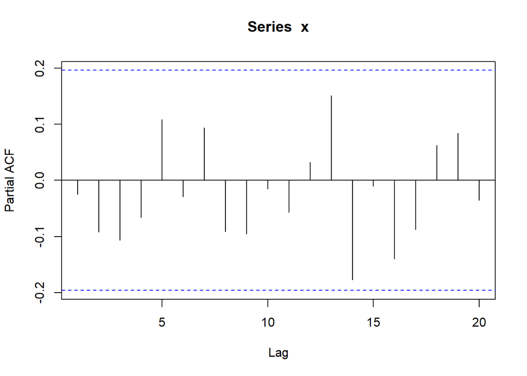

```r
set.seed(12345)
x <- rnorm(100)
pacf(x)    # moznost 1
```

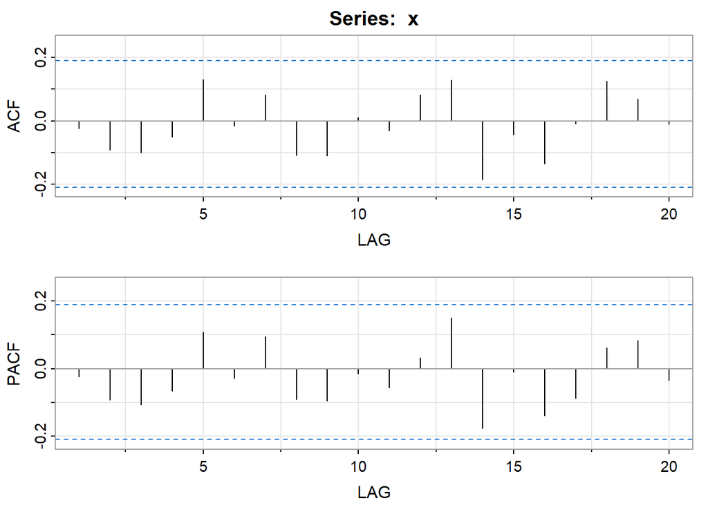

```
##       [,1]  [,2]  [,3]  [,4] [,5]  [,6] [,7]  [,8]  [,9] [,10] [,11] [,12]
## ACF  -0.02 -0.09 -0.10 -0.05 0.13 -0.02 0.08 -0.11 -0.11  0.01 -0.03  0.08
## PACF -0.02 -0.09 -0.11 -0.07 0.11 -0.03 0.09 -0.09 -0.10 -0.02 -0.06  0.03
##      [,13] [,14] [,15] [,16] [,17] [,18] [,19] [,20]
## ACF   0.13 -0.19 -0.04 -0.13 -0.01  0.12  0.07 -0.01
## PACF  0.15 -0.18 -0.01 -0.14 -0.09  0.06  0.08 -0.04
```

```r
acf2(x)    # moznost 2
```

## 8.4 ACF, PACF: Kontrolná otázka

ACF aj PACF sa v R-ku počítajú numericky. Ktoré z nasledujúcich postupností sa po určitom počte členov vynulujú (a teda tie malé čísla sú v skutočnosti nuly) a ktoré majú hodnoty, ktoré konvergujú k nule, ale neexistuje index, od ktorého by boli nulové?

**Príklad 1**

```r
ARMAacf(ar=c(0.05,-0.2), lag.max=10)
```

```
##             0             1             2             3             4
##  1.0000000000  0.0416666667 -0.1979166667 -0.0182291667  0.0386718750
##             5             6             7             8             9
##  0.0055794271 -0.0074554036 -0.0014886556  0.0014166479  0.0003685635
##            10
## -0.0002649014
```

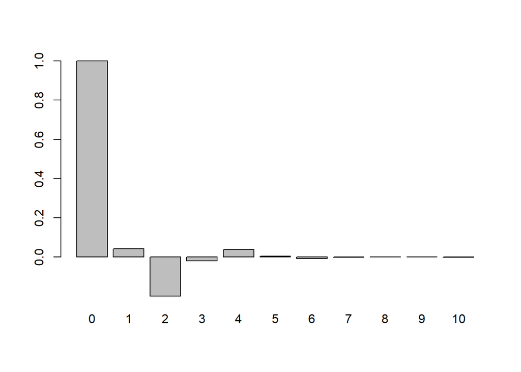

```r
barplot(ARMAacf(ar=c(0.05,-0.2), lag.max=10))
```

**Príklad 2**

```r
ARMAacf(ar=c(0.3,0.05), lag.max=10, pacf=TRUE)
```

```
##  [1]  3.157895e-01  5.000000e-02 -3.863413e-18  3.927096e-19 -4.622862e-19
##  [6] -1.450362e-19 -4.829267e-20  6.640242e-20  5.131096e-20 -2.263719e-20
```

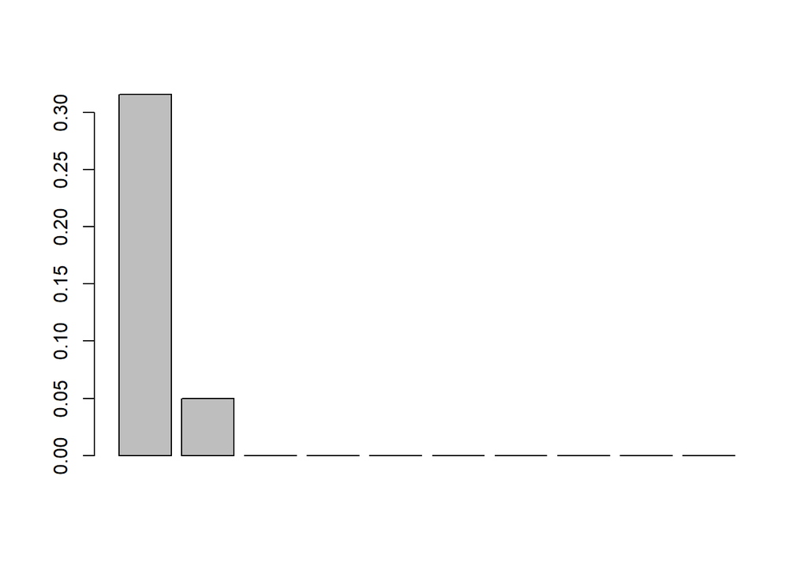

```r
barplot(ARMAacf(ar=c(0.3,0.05), lag.max=10,pacf=TRUE))
```

# 9 Stacionarita AR(2) procesu - simulácie

Vytvoríme funkciu, ktorá pre zadaný vektor parametrov $(\alpha_1, \alpha_2)$ vráti `TRUE`, resp. `FALSE` podľa toho, či je AR(2) proces s týmito koeficientami stacionárny alebo nie.

```r
stacAR2 <- function(alpha12) {
# vstup: dvojzložkový vektor koeficientov
# výstup: TRUE/FALSE podľa stacionarity
....
}
```

Otestujte:

```r
stacAR2(c(1.2, -0.5))
```

```
## [1] TRUE
```

```r
stacAR2(c(1.2, 0.5))
```

```
## [1] FALSE
```

```r
stacAR2(c(0.5, 0)) # AR(1), ale stacionárny
```

```
## [1] TRUE
```

```r
stacAR2(c(0, 0))   # konštanta + biely šum -> stacionárny
```

```
## [1] TRUE
```

Spravíme sieť bodov $(\alpha_1, \alpha_2)$ a zakreslíme, ktoré sú stacionárne a ktoré nie sú. Na vytvorenie dvojíc bodov použijeme náhodne generované čísla z rovnomerného rozdelenia na štvorci $(-2,2)\times(-2,2)$.

```r
set.seed(123)
alfa1 <- runif(1000, min = -2, max = 2)
alfa2 <- runif(1000, min = -2, max = 2)
df <- data.frame(alfa1, alfa2)
head(df)
```

```
##        alfa1       alfa2
## 1 -0.8496899 -0.90550906
## 2  1.1532205  0.37546773
## 3 -0.3640923 -1.35926075
## 4  1.5320696  1.41372096
## 5  1.7618691  1.39095663
## 6 -1.8177740 -0.08845275
```

Teraz pridáme do *data framu* tretí stĺpec, v ktorom bude výsledok overovania stacionarity. Namiesto `for`-cyklu použijeme funkciu `apply`. Tá umožňuje aplikovať zadanú funkciu na riadky alebo stĺpce objektu (matica, data frame).

**Vsuvka: Ukážka použitia funkcie `apply`**

```r
set.seed(123)
dfUkazka <- data.frame(a = sample.int(5),
                       b = sample.int(5),
                       c = sample.int(5))
dfUkazka # nejaké čísla
```

```
##   a b c
## 1 3 3 2
## 2 2 1 3
## 3 5 2 1
## 4 4 5 4
## 5 1 4 5
```

```r
f <- function(x) (x[1] + x[2]) * x[3] # nejaká funkcia

# POUŽITIE APPLY
apply(dfUkazka,   # vstupné dáta pre funkciu
      MARGIN = 1, # po riadkoch
      FUN = f)    # použitá funkcia
```

```
## [1] 12  9  7 36 25
```

```r
# priradenie ako nový stĺpec
dfUkazka$vysledok <- apply(dfUkazka, 1, f)
dfUkazka
```

```
##   a b c vysledok
## 1 3 3 2       12
## 2 2 1 3        9
## 3 5 2 1        7
## 4 4 5 4       36
## 5 1 4 5       25
```

```r
# ĎALŠIE POUŽITIE APPLY: teraz nie je vstupom celý riadok
g <- function(x) x[2]/x[1] + x[1] # zase nejaká funkcia
dfUkazka$vysledok2 <- apply(dfUkazka[ , 3:4], 1, g)
dfUkazka
```

```
##   a b c vysledok vysledok2
## 1 3 3 2       12         8
## 2 2 1 3        9         6
## 3 5 2 1        7         8
## 4 4 5 4       36        13
## 5 1 4 5       25        10
```

**Vrátime sa k overovaniu stacionarity.**

Pomocou `apply` a vytvorenej funkcie `stacAR2` pridajte do *data framu* `df` stĺpec `stacionarita` s informáciou o stacionarite procesu s danymi parametrami.

Mali by ste dostať

```r
head(df)
```

```
##        alfa1       alfa2 stacionarita
## 1 -0.8496899 -0.90550906         TRUE
## 2  1.1532205  0.37546773        FALSE
## 3 -0.3640923 -1.35926075        FALSE
## 4  1.5320696  1.41372096        FALSE
## 5  1.7618691  1.39095663        FALSE
## 6 -1.8177740 -0.08845275        FALSE
```

Vykreslite body farebne odlíšené podľa toho, či je proces stacionárny (modrá) alebo nie (červená). Do obrázka pridajte čiernou nerovnosti odvodené teoreticky.

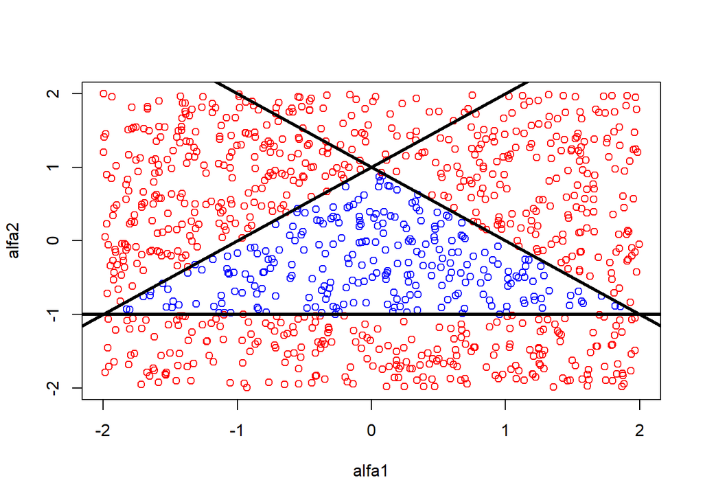

# 10 Ďalšie príklady

## 10.1 Nájdenie procesu s danou vlastnosťou

Nájdite príklad procesov, ktoré majú nasledovné vlastnosti. Pre každý proces dokážte, že má naozaj požadovanú vlastnosť.

- Autoregrený proces, ktorého PACF pre lag 3 je nulová.
- Autoregrený proces prvého rádu, ktorého PACF pre lag 1 je rovná 0.5.
- Autoregresný proces, ktorého ACF je vždy kladná.
- Autoregresný proces, ktorého ACF nie je monotónna.

## 10.2 Overovanie stacionarity AR procesov II.

### 10.2.1 Analyticky

Odvoďte podmienku stacionarity AR(2) procesu v tvare lineárnych nerovníc pre autoregresné koeficienty a zakreslite do roviny (na jednotlivých osiach sú hodnoty autoregresných koeficientov) tie body, ktoré zodpovedajú stacionárnym procesom. Porovnajte so simuláciami, ktoré sa robili v cvičení 9.

### 10.2.2 Simulačne

Ak riešime úlohy typu *“pre aké hodnoty parametra je daný proces stacionárny”* analyticky, je dobré mať numerickú kontrolu.

**Príklad**: Pre aké hodnoty parametra $k$ je proces $x_t = x_{t−1} + kx_{t−2} + u_t$ stacionárny?

Vytvorte funkciu `armaRoots`, ktorá vypočíta korene charakteristickej rovnice $1-L-kL^2=0$ a vráti ich absolútne hodnoty. (Hint: funkcia `Mod`)

```r
armaRoots <- function(k) {
  ...
  return(...)
}
```

Následne vytvorte vektor hodnôt `kVektor` (od -2 po 2) a pre každú jeho zložku nájdite absolútne hodnoty koreňov. Výsledok zapíšte do objektu `root_abs_vals`. Dostanete

```
## [[1]]
## [1] 0.7071068 0.7071068
##
## [[2]]
## [1] 0.7254763 0.7254763
##
## [[3]]
## [1] 0.745356 0.745356
##
## [[4]]
## [1] 0.766965 0.766965
##
## [[5]]
## [1] 0.7905694 0.7905694
##
## [[6]]
## [1] 0.8164966 0.8164966
```

Keďže objekt `root_abs_vals` je zoznam, prvý a druhý koreň z neho extrahujeme nasledovným príkazom, čím dostávame dva vektory rovnakej dĺžky.

```r
root1 <- sapply(root_abs_vals, function(x) x[1])  # Prvý koreň
root2 <- sapply(root_abs_vals, function(x) ifelse(length(x) == 2, x[2], x[1]))  # Druhý koreň (osetreny pripad dvojnasobneho korena)
```

Vektory `root` a `root2` teraz môžeme vykresliť vzhľadom k parametru $k$. Doplníme tiež horizontálnu čiaru znázorňujúcu hranicu stability a vertikálne čiary pre tri konkrétne hodnoty parametra $k$.

Skontrolujte, či sa vaše výpočty zhodujú s numerickými na nasledujúcom obrázku. Prečo pre niektoré je len jedna absolútna hodnota (napríklad $k=-1.5$ - modrá), kým pre iné sú dve ($k=-0.2$ - zelená, $k=0.5$ - hnedá)?

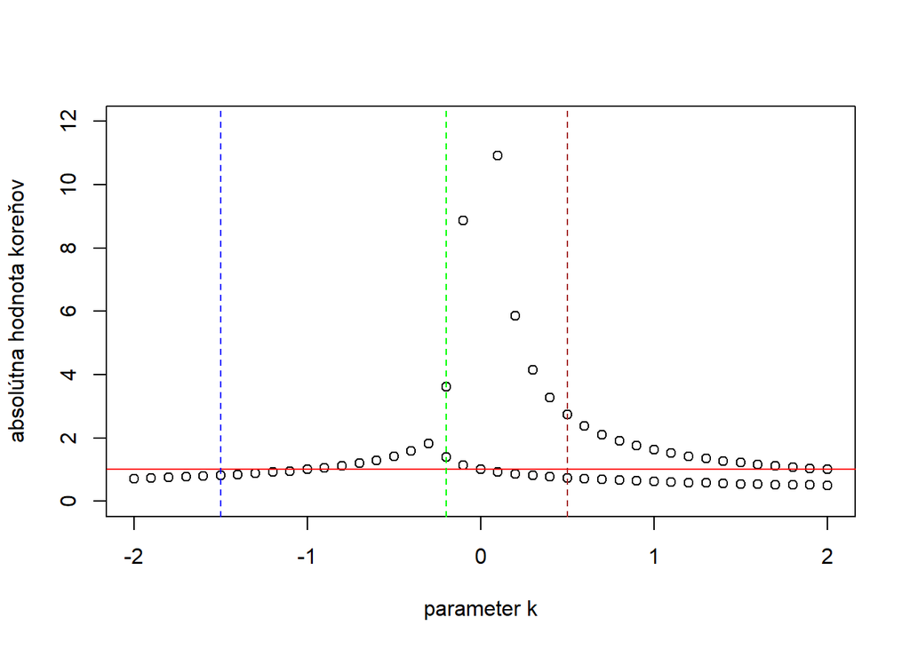

```r
plot(kVektor, root1, type="p", col='black', ylim=c(0, 12),
     xlab="parameter k", ylab="absolútna hodnota koreňov")
lines(kVektor, root2, type="p", col='black')  # Pridaj druhý koreň

abline(h=1, col="red")              # horizontálna čiara znázorňujúca hranicu stability (absolútna hodnota koreňov > 1)
abline(v=-1.5, col="blue", lty=2)   # Vertikálna čiara pre k = -1.5
abline(v=-0.2, col="green", lty=2)  # Vertikálna čiara pre k = -0.2
abline(v=0.5, col="brown", lty=2)   # Vertikálna čiara pre k = 0.5
```

## 10.3 Hľadanie AR modelu pre zadané dáta

Všetky nasledujúce dáta majú spoločné zadanie:

- nájsť vhodný autoregresný model pre zadané dáta
- vysvetliť, prečo sú rezíduá vyhovujúce - okomentovať ACF rezíduí aj Ljung-Boxov test, pričom treba presne povedať, aká hypotéza sa testuje a či sa v tomto prípade zamieta alebo nie (a prečo sme s tým výsledkom spokojní)
- overiť stacionaritu získaného modelu (napísať polynóm, ktorého korene overujete, aké absolútne hodnoty koreňov vyšli a prečo sme s tým spokojní)
- spraviť predikcie

V prípade modelovania diferencií sa treba na základe prítomnosti, resp. neprítomnosti trendu treba rozhodnúť, či do modelu zahrnúť konštantu alebo nie.

### 10.3.1 Hladina Hurónskeho jazera

Dáta z knižnice `datasets`. Z popisu v helpe: Annual measurements of the level, in feet, of Lake Huron 1875–1972. Použijeme dáta od roku 1900.

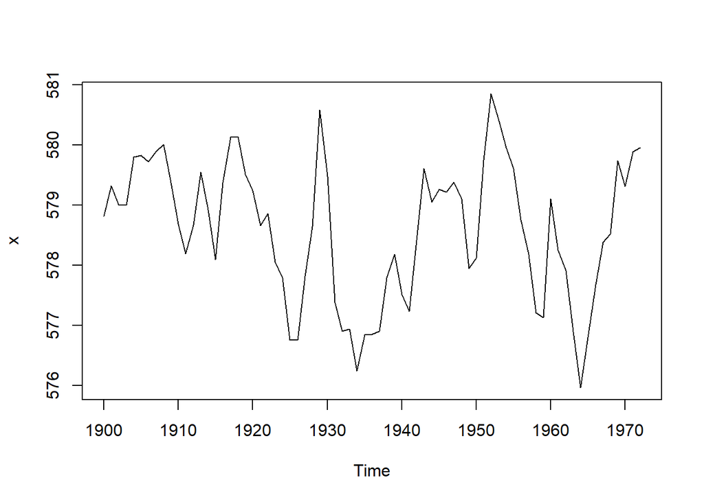

```r
x <- window(LakeHuron, start = 1900)
plot(x)
```

Dáta nediferencujeme, AR model hľadáme priamo pre tieto dáta.

### 10.3.2 Indikátor od Boxa a Jenkinsa

Dáta z knižnice `astsa`, z popisu v helpe: Leading indicator, 150 months; taken from Box and Jenkins (1970).

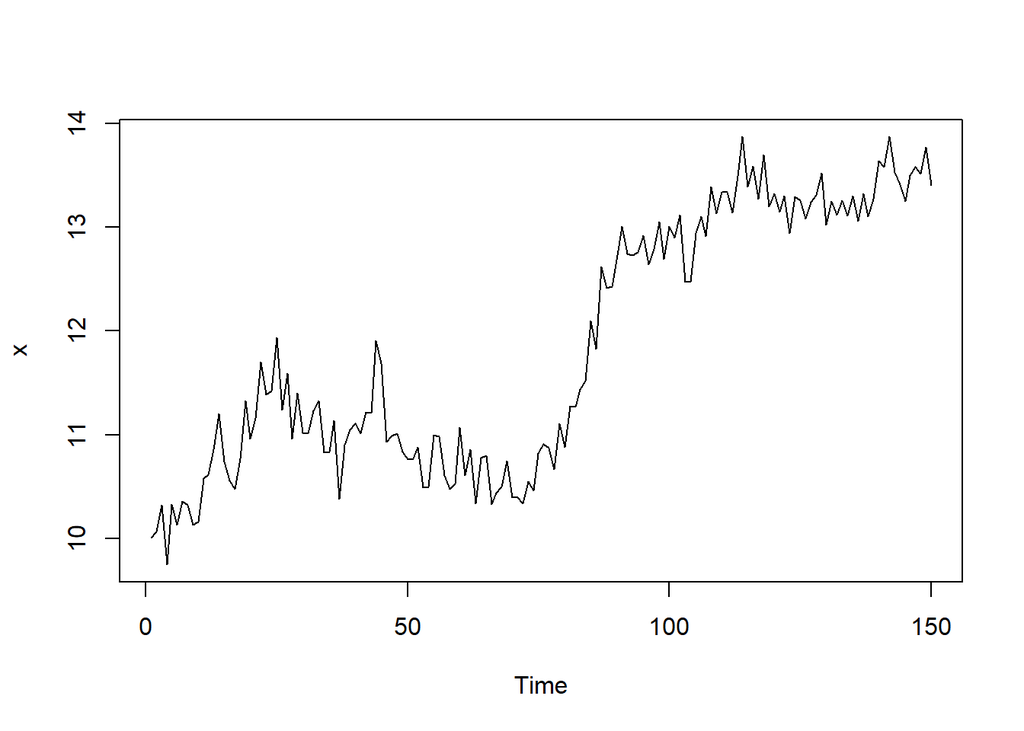

```r
x <- lead
plot(x)
```

Nájdite model pre premennú `x` tak, že budete jej diferencie modelovať AR procesom.

### 10.3.3 Ceny ropy

Dáta z knižnice `astsa`, z popisu v helpe: Crude oil, WTI spot price FOB (in dollars per barrel), weekly data from 2000 to mid-2010.

Zoberieme dáta od roku 2006.

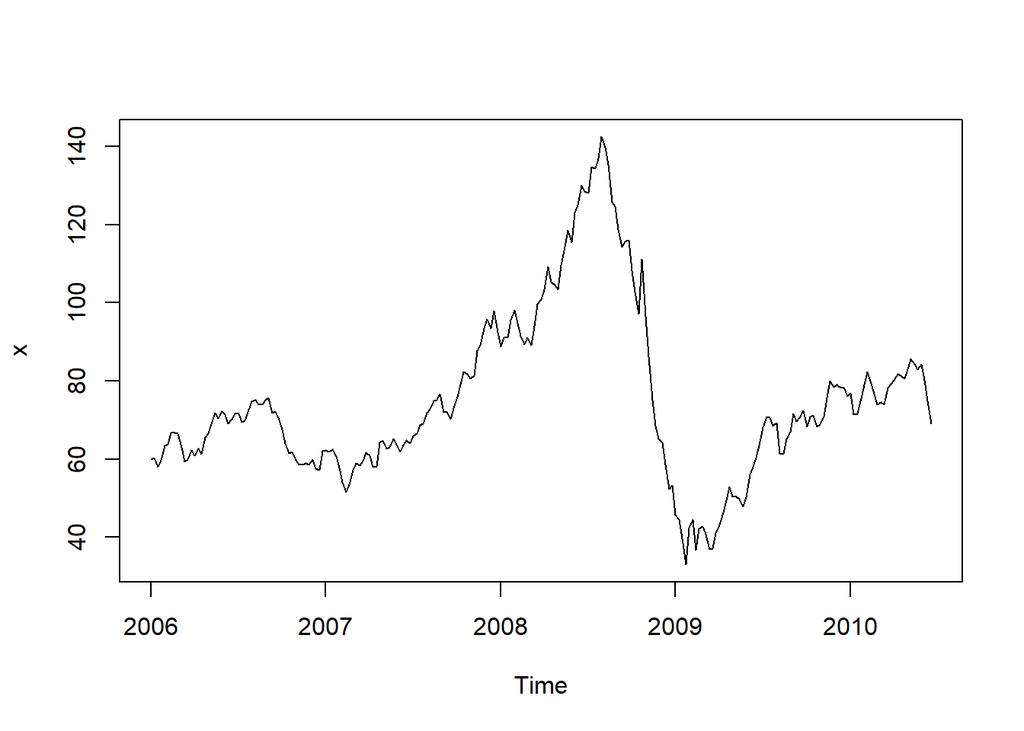

```r
x <- window(oil, start = c(2006, 1))
plot(x)
```

Nájdite model pre premennú `x` tak, že budete jej diferencie modelovať AR procesom.

# 11 Dodatky

## 11.1 Pristupovanie ku koeficientom modelu

Pri AR(1) modeli sme hneď videli, či je stacionárny alebo nie. Pri modeloch vyššieho rádu použijeme funkciu `polyroot`. Hodnoty koeficientov však nemusíme odpisovať, tak by sme navyše dostali iba ich približné hodnoty.

```r
model.ar3 <- sarima( x, 3,1,0, details=FALSE)
```

```
## <><><><><><><><><><><><><><>
##
## Coefficients:
##          Estimate     SE t.value p.value
## ar1        0.1656 0.0655  2.5283  0.0121
## ar2        0.0563 0.0665  0.8473  0.3977
## ar3        0.0871 0.0658  1.3241  0.1868
## constant   0.0212 0.3308  0.0641  0.9490
##
## sigma^2 estimated as 12.19486 on 228 degrees of freedom
##
## AIC = 5.382287  AICc = 5.383047  BIC = 5.456571
##
```

Pozrite si štruktúru `str(model.ar3)` objektu `model.ar3`. Následne vyberte z výstupu `model.ar3` vektor odhadnutých parametrov modelu. Z tohto chceme tie zložky vektora, ktorých názvy obsahujú `ar`

```
##        ar1        ar2        ar3   constant
## 0.16557547 0.05630823 0.08710237 0.02120166
```

Pre AR(p) model sa dá napísať `koef[1:p]`. Budeme mať aj všeobecnejšie modely (koeficienty budú s názvami `ma1`, `ma2`, … neskôr aj napríklad `sar1`, `sma1`). Napríklad

```r
model.zlozitejsi <- sarima( x, 3,1,2,1,0,1, 1,details=FALSE)
```

```
## <><><><><><><><><><><><><><>
##
## Coefficients:
##          Estimate     SE t.value p.value
## ar1       -0.1149 0.2058 -0.5580  0.5774
## ar2        0.8847 0.0668 13.2472  0.0000
## ar3        0.0288 0.1648  0.1750  0.8612
## ma1       -0.0635 0.3945 -0.1609  0.8723
## ma2       -0.5857 0.3336 -1.7556  0.0805
## sar1      -0.6248 0.5016 -1.2457  0.2142
## sma1       0.9610 0.0542 17.7252  0.0000
## constant  -0.0024 0.4656 -0.0050  0.9960
##
## sigma^2 estimated as 11.85058 on 224 degrees of freedom
##
## AIC = 5.38931  AICc = 5.392093  BIC = 5.523019
##
```

```r
koef.zlozitejsie <- model.zlozitejsi$fit$coef
koef.zlozitejsie
```

```
##          ar1          ar2          ar3          ma1          ma2         sar1
## -0.114855734  0.884714782  0.028837186 -0.063466694 -0.585713988 -0.624833726
##         sma1     constant
##  0.960964357 -0.002350561
```

Počet členov jednotlivých typov je daný našou špecifikáciou modelu, takže sa znovu dá spočítať, ktoré zložky zodpovedajú členom `ar`, ktor `ma` atď. Alternatívou je použiť *regulárne výrazy* a automaticky vybrať napríklad zložky, ktorých názov začína `ar`, zložky, ktorých názov začína `ma` atď. Ak by sme chceli indexy tých, ktoré obsahujú `ma`, spravili by sme

```r
grep("ma",                     # co sa ma hladat
    names(koef.zlozitejsie))   # kde sa to ma hladat
```

```
## [1] 4 5 7
```

My ale chceme iba tie, ktoré začínajú `ma` (lebo je tam aj `sma1` koeficient, ktorý nechceme). Tu prichádzajú na rad regulárne výrazy

```r
grep("^ma",                     # co sa ma hladat
    names(koef.zlozitejsie))   # kde sa to ma hladat
```

```
## [1] 4 5
```

Príslušné koeficienty potom sú

```r
koef.zlozitejsie[grep("^ma",names(koef.zlozitejsie))]
```

```
##         ma1         ma2
## -0.06346669 -0.58571399
```

Viac o regulárnych výrazov v R-ku: https://r4ds.had.co.nz/strings.html#matching-patterns-with-regular-expressions

## 11.2 Dáta Svetovej banky a grafy pomocou balíka `ggplot2`

Knižnica `WDI` v R-ku slúži na priamy prístup k dátam zo Svetovej banky (World Bank). Knižnica obsahuje informácie o viac ako 200 krajinách a viacerých regiónoch, pokrýva obdobie od roku 1960 po súčasnosť a obsahuje rôzne ukazovatele, ako sú HDP, inflácia, nezamestnanosť, úroveň vzdelania, prístup k vode, emisie CO2, atď.

### 11.2.1 Vyhľadávanie dát

Na vyhľadávanie názvov a popisov dostupných databáz v rámci knižnice `WDI` slúži funkcia `WDI.search`.

Ak napríklad hľadáme indikátory, ktoré majú v názve “gdp” použijeme

```r
WDIsearch('gdp')
```

Dajú sa použiť aj regulárne výrazy (viac o regulárnych výrazov v R-ku: https://r4ds.had.co.nz/strings.html#matching-patterns-with-regular-expressions). Napríklad, ak je úlohou nájsť indikátory, ktoré hovoria o HDP na obyvateľa, vypíšme si tie, ktoré obsahujú reťazce “gdp” a “capita”.

```r
WDIsearch('gdp.*capita')
```

Ak je veľa výsledkov, môžeme vypísať niekoľko prvých

```r
WDIsearch('gdp.*capita')[1:6,]
```

### 11.2.2 Načítanie dát

Dáta z knižnice `WDI` načítame príkazom `WDI`. Ukážka:

```r
data.hdp <- WDI( country = c("FI","US","FR", "DE"),
                 indicator = "NY.GDP.PCAP.KD",
                 start = 1975)
```

Argumenty funkcie:

- `country` - vektor kódov štátov vo formáte iso2c. Kódy sa dajú nájsť napríklad tu: https://datahub.io/core/country-list alebo pomocou knižnice `countrycode` v R-ku (https://vincentarelbundock.github.io/countrycode/#/)
- `indicator` - vektor indikátorov, ktoré sme našli pomocou funkcie `WDIsearch`
- `start` - počiatočný rok (default je 1960)
- ďalšie argumenty (pozri `?WDI`)

```r
head(data.hdp)
```

```
##   country iso2c iso3c year NY.GDP.PCAP.KD
## 1 Germany    DE   DEU 2025       44146.64
## 2 Germany    DE   DEU 2024       44027.76
## 3 Germany    DE   DEU 2023       44368.99
## 4 Germany    DE   DEU 2022       44817.13
## 5 Germany    DE   DEU 2021       44011.02
## 6 Germany    DE   DEU 2020       42372.87
```

### 11.2.3 Grafy pomocou balíka `ggplot`

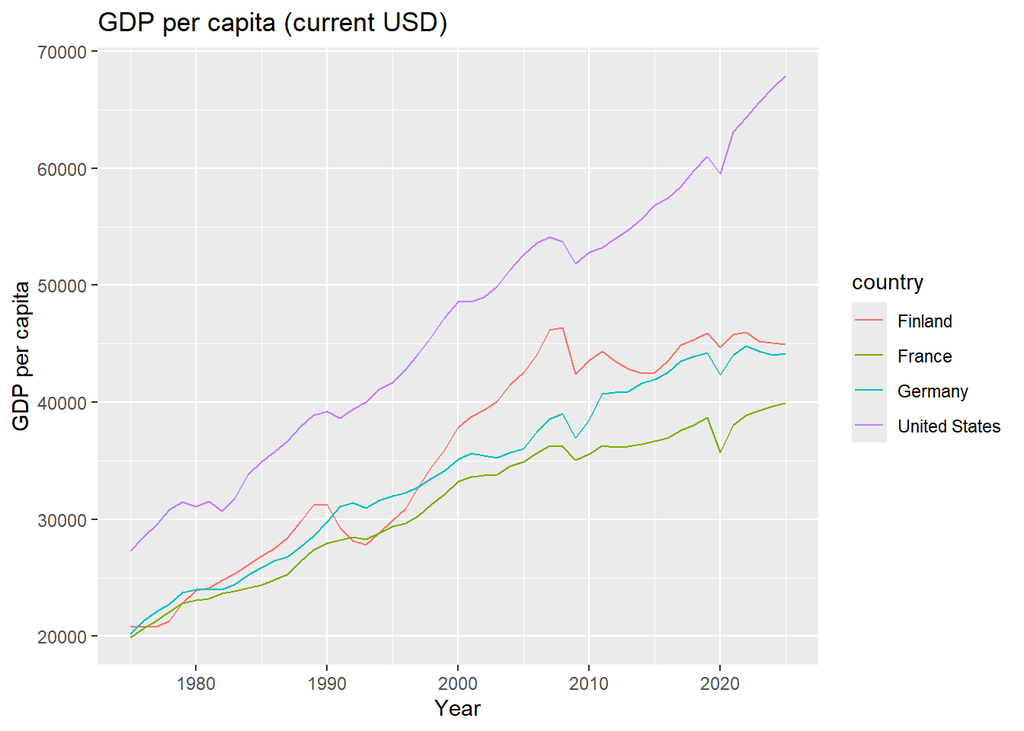

```r
ggplot(data.hdp, aes(year, data.hdp$NY.GDP.PCAP.KD, color = country)) +
  geom_line() +
  xlab('Year') + ylab('GDP per capita') +
  labs(title = 'GDP per capita (current USD)')
```

Viac o balíku `ggplot2` napríklad tu: https://www.rdocumentation.org/packages/ggplot2/versions/3.5.0

## 11.3 Porovnanie rýchlosti for-cyklu a funkcie apply

Nasledovný kód porovnáva dva spôsoby určovania stability AR(2) modelu – pomocou vektorovej operácie `apply` a pomocou explicitného `for` cyklu.

Funkcia `stacAR2` testuje, či je AR(2) proces stabilný na základe jeho parametrov. Vstupom tejto funkcie je vektor parametrov, výstupom je logický operátor `TRUE/FALSE`.

```r
stacAR2 <- function(par) all(abs(polyroot(c(1, -par))) > 1)
```

Vo funkciách nazvaných `verzia1` a `verzia2` sa následne generujú dva náhodné vektory $x$ a $y$ s normálnym rozdelením, z ktorých sa vytvorí dataframe `df`. Rozdiel nastáva v tom, že zatiaľ čo `verzia1` aplikuje funkciu `stacAR2` po riadkoch dataframu `df` pomocou príkazu `apply`, `verzia2` aplikuje na každý riadok explicitný `for` cyklus. Výsledkom je v oboch prípadoch logický vektor, ktorý pre každý riadok udáva, či sú príslušné parametre stabilné.

```r
verzia1 <- function(N){
  set.seed(12345)
  x <- rnorm(N)
  y <- rnorm(N)
  df <- data.frame(x,y)
  stac <- apply(df, 1, stacAR2)
  return(stac)
}

verzia2 <- function(N){
  set.seed(12345)
  x <- rnorm(N)
  y <- rnorm(N)
  df <- data.frame(x,y)
  stac <- rep(0, N)
  for(i in 1:N) stac[i] <- stacAR2(as.numeric(df[i,]))
  return(stac)
}
```

Použijeme balík `microbenchmark` na meranie času, ktorý zaberie vykonanie funkcií `verzia1` a `verzia2` s veľkosťou vstupu `N = 100 (10^2)`. Výsledky vizualizujeme pomocou boxplotu.

```r
library(microbenchmark)
cas2 <- microbenchmark(verzia1(10^2), verzia2(10^2))
cas2
```

```
## Unit: microseconds
##           expr    min      lq     mean  median      uq     max neval
##  verzia1(10^2)  473.2  517.95  714.161  544.95  596.60 11095.5   100
##  verzia2(10^2) 2144.0 2219.65 2527.999 2374.35 2563.95  7468.7   100
```

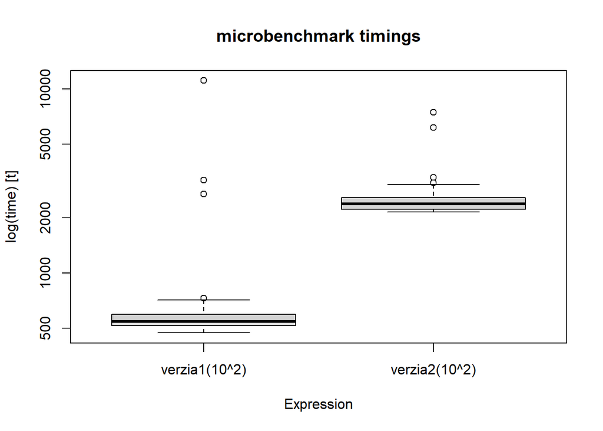

```r
boxplot(cas2)
```

Zo štatistík vidíme, že `verzia1` je podstatne efektívnejšia ako `verzia2` – napríklad priemerný čas vykonania je pri `verzii1` asi štvornásobne kratší.

```r
cas4 <- microbenchmark(verzia1(10^4), verzia2(10^4))
cas4
```

```
## Unit: milliseconds
##           expr      min        lq      mean   median       uq      max neval
##  verzia1(10^4)  29.0531  29.60555  31.61182  30.1023  33.9385  39.1759   100
##  verzia2(10^4) 210.6451 213.44585 220.94789 215.1422 218.9688 348.9437   100
```

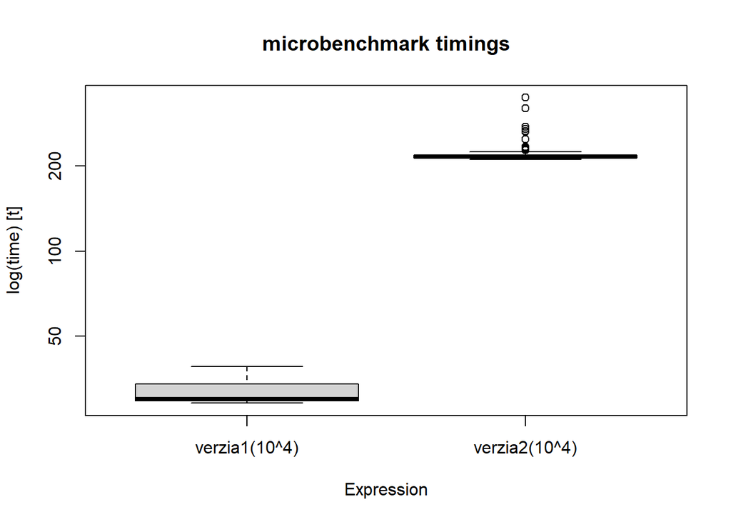

```r
boxplot(cas4)
```

Pre väčšie vstupy je tento rozdiel ešte výraznejší, čo ukazuje, že vektorové operácie sú v R efektívnejšie ako explicitné cykly.

Viac o funkcii apply a príbuzných funkciách napríklad tu: https://www.datacamp.com/community/tutorials/r-tutorial-apply-family